# STK-IN4300

Assignment 1

Kyunhee Park

2024-09-18

```r
# Data load and process
knitr::opts_chunk$set(echo = TRUE)

data_raw <- read.csv(here("data/SeoulBikeData.csv"), fileEncoding = "UTF-8")

data <- data_raw %>% dplyr::filter(Functioning.Day == "Yes") %>%                # filter out invalid
  dplyr::select(-Functioning.Day)                                           # drop unnecessary col

data$Date <- as.factor(data$Date)
data$Seasons <- as.factor(data$Seasons) # categorical variable: factorize
data$Holiday <- as.factor(data$Holiday) # categorical variable: factorize
data$Hour <- as.factor(data$Hour)
```

# 1. Summary Statistics Table

Summarizes the information in the data on a variable level.

## 1.1 Dataset description

- Bike rental counts in a city.
- Time series data: 01.12.2017 - 30.11.2018.
- A day is divided to one-hour length time slot.
- Possible use case: Prediction of rental bike demands, on certain time or seasons.

### 1.1.1 Target variable

- Rented.Bike.Count: Target variable

### 1.1.2 Categorical variables

- Date: Date in sequence, 01.12.2017 - 30.11.2018.
- Hour: 0-23 (12AM - 11PM). Reasonable to treat this variable as a categorical variable.
- Seasons: Autumn, Winter, Spring, Summer -> Transform to a factor variable, by applying as.factor()
- Holiday: No Holiday, Holiday -> Transform to a factor variable, by applying as.factor()
- Functioning.Day: Yes, No -> “No” rows will be filtered out, as no additional information is obtainable.

### 1.1.3 Continous variables

- Temperature
- Humidity
- Wind.speed
- Visibility
- Dew.point.temperature
- Solar.Radiation
- Rainfall
- Snowfall

## 1.2 Summary Statistics Table.

The table below shows the summary table of preprocessed dataset.

```r
summary(data)
```

```
##          Date      Rented.Bike.Count      Hour      Temperature.C.
##  01/01/2018:  24   Min.   :   2.0    7      : 353   Min.   :-17.80
##  01/02/2018:  24   1st Qu.: 214.0    8      : 353   1st Qu.:  3.00
##  01/03/2018:  24   Median : 542.0    9      : 353   Median : 13.50
##  01/04/2018:  24   Mean   : 729.2    10     : 353   Mean   : 12.77
##  01/05/2018:  24   3rd Qu.:1084.0    11     : 353   3rd Qu.: 22.70
##  01/06/2018:  24   Max.   :3556.0    12     : 353   Max.   : 39.40
##  (Other)   :8321                     (Other):6347
##   Humidity...    Wind.speed..m.s. Visibility..10m. Dew.point.temperature.C.
##  Min.   : 0.00   Min.   :0.000    Min.   :  27     Min.   :-30.600
##  1st Qu.:42.00   1st Qu.:0.900    1st Qu.: 935     1st Qu.: -5.100
##  Median :57.00   Median :1.500    Median :1690     Median :  4.700
##  Mean   :58.15   Mean   :1.726    Mean   :1434     Mean   :  3.945
##  3rd Qu.:74.00   3rd Qu.:2.300    3rd Qu.:2000     3rd Qu.: 15.200
##  Max.   :98.00   Max.   :7.400    Max.   :2000     Max.   : 27.200
##
##  Solar.Radiation..MJ.m2.  Rainfall.mm.     Snowfall..cm.       Seasons
##  Min.   :0.0000          Min.   : 0.0000   Min.   :0.00000   Autumn:1937
##  1st Qu.:0.0000          1st Qu.: 0.0000   1st Qu.:0.00000   Spring:2160
##  Median :0.0100          Median : 0.0000   Median :0.00000   Summer:2208
##  Mean   :0.5679          Mean   : 0.1491   Mean   :0.07769   Winter:2160
##  3rd Qu.:0.9300          3rd Qu.: 0.0000   3rd Qu.:0.00000
##  Max.   :3.5200          Max.   :35.0000   Max.   :8.80000
##
##        Holiday
##  Holiday   : 408
##  No Holiday:8057
##
##
##
##
##
```

# 2. Bad Data Visualization

For at least one categorical and one continuous variable in your data, make a bad plot and explain why it is bad and possibly even misleading.

## 2.1 Bad Data Visualization - Categorical variable

- X axis: Holiday/No Holiday
- Y axis: Average Rented.Bike.Count

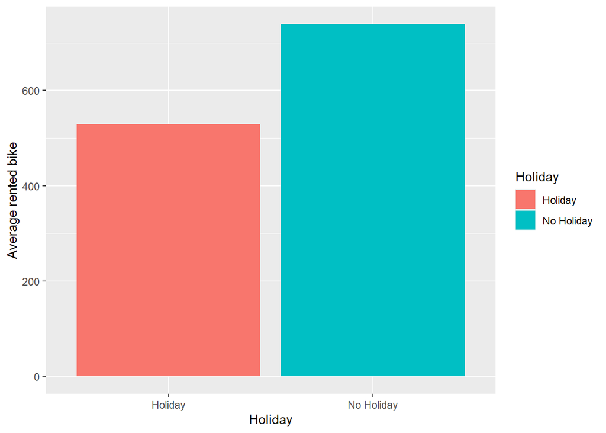

```r
ggplot2::ggplot(data %>%
                  dplyr::group_by(Holiday) %>%
                  dplyr::summarise(
                    avg_rent = mean(Rented.Bike.Count)),
                ggplot2::aes(x = Holiday, y = avg_rent, fill = Holiday)) +
  ggplot2::geom_bar(stat = "identity") +
  ggplot2::labs(x = "Holiday", y = "Average rented bike")
```

- Does not provide information regarding seasonal effect.
- Lack of information regarding distribution, Quantile, Median, Min, Max

## 2.2 Bad Data Visualization - Continous variable

- X axis: Temperature
- Y axis: Rented.Bike.Count

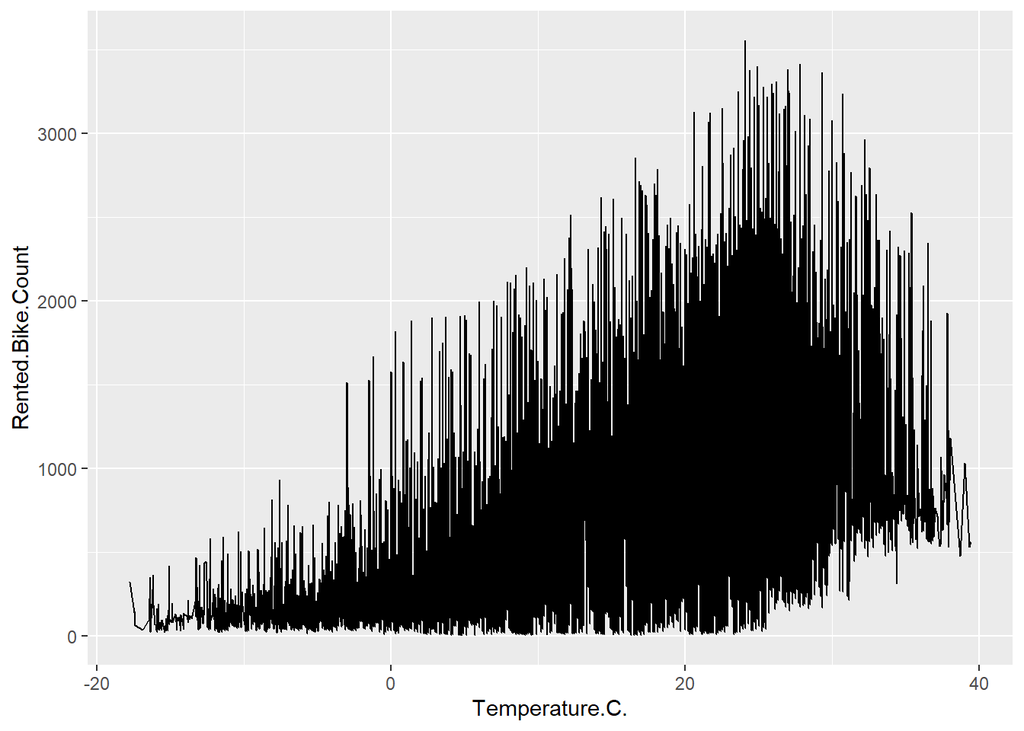

```r
ggplot2::ggplot(data = data,
  ggplot2::aes(x = Temperature.C., y = Rented.Bike.Count)) +
  ggplot2::geom_line()
```

- Does not include seasonal effect.
- Rented.Bike.Count increases as the temperature increases, but no additional information is obtainable.

# 3. Good Data Visualization

Provide a good version of the bad plot(s) from Problem 2 and explain how the plot has been improved.

## 3.1 Good Data Visualization - Categorical variable

### 3.1.1 Improvements

- Include seasonal effect.
- Provide the distribution of the bike rentals per Seasons.
- Provide the distribution of the bike retnals per Hour.

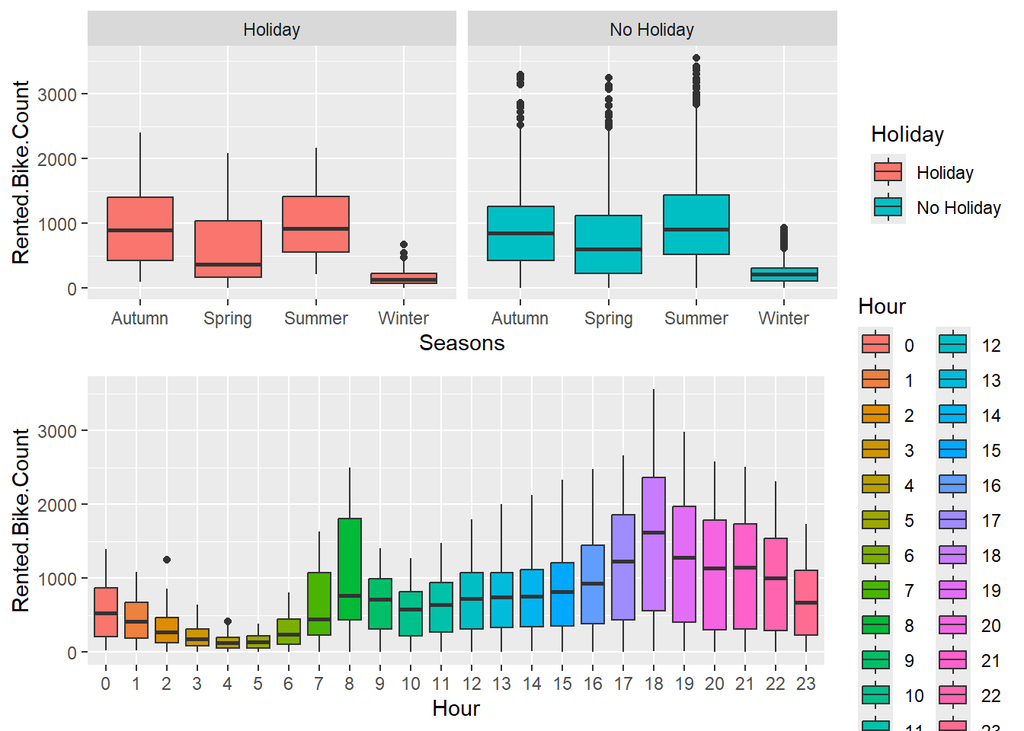

```r
plot_Seasons_Holiday_boxplot <-
  ggplot2::ggplot(data,
                  ggplot2::aes(x = Seasons, y = Rented.Bike.Count, fill = Holiday)) +
  ggplot2::geom_boxplot() +
  ggplot2::facet_wrap(~ Holiday)

plot_Hour_boxplot <-
  ggplot2::ggplot(data,
                  ggplot2::aes(x = Hour, y = Rented.Bike.Count, fill = Hour)) +
  ggplot2::geom_boxplot()

grid.arrange(plot_Seasons_Holiday_boxplot, plot_Hour_boxplot, nrow = 2)
```

### 3.1.2 Interpretation

- No Holiday has overall higher demands.
- The ranges of 25th quantile-75th quantile are similar in both on Holiday/No Holiday.
- More frequent extreme values in No Holiday, likely to be during the rush-hour.
- The demand for bike rental is highest during the rush-hour, Hour variable 8 and 18.

## 3.2 Good Data Visualization - Continous variable

- Each point corresponds to one observation.
- Ex) In Autumn, there are observations above 3000 when the temperature is around 25. Likely to be during the rush-hour.

### 3.1.1 Improvements

- Include the seasonal effect.
- Provide the distribution of Rented.Bike.Count.

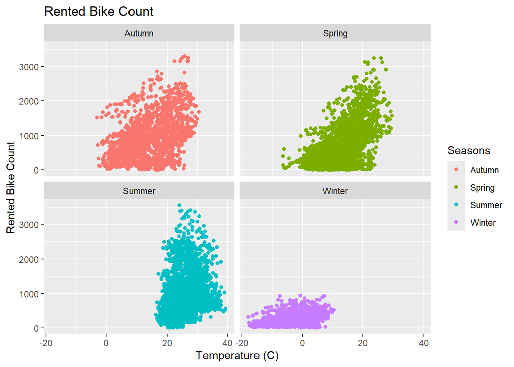

### 3.2.1 Interpretations

- The range of temperature is similar in the Autumn and Spring.
- In summer, there are more observations above 2500 Compare to Autumn and Spring.
- In winter, bike rentals observations are relatively low, below 1000.

# 4. Simple analysis

Perform linear regression on the data, including some method for performing model selection. Include some measure of performance on the final model. Based both on the analysis and your previous visualizations, evaluate whether a linear model is sufficient.

## 4.1 Data preprocessing

### 4.1.1 Categorical variable.

- Four categorical variables: Date, Seasons, Holiday, Hour.
- Drop Date variable: Considered not necessary. Including this variable will generate excessive predicators.
- Factorize the categorical variables: Seasons, Holiday, Hour.

```r
data <- data %>% dplyr::select(-Date)           # drop Date variable.
data$Seasons <- as.factor(data$Seasons) # categorical variable: factorize
data$Holiday <- as.factor(data$Holiday) # categorical variable: factorize
data$Hour <- as.factor(data$Hour)

df_x_cate <- data %>% dplyr::select(where(is.factor))
```

### 4.1.2 Continous variable.

- Select the continous variables.
- Deselect the response variable.
- Apply scaling to the continous variables.

```r
df_x_cont <- data %>% dplyr::select(where(~!is.factor(.))) %>%   # Continous variables
  dplyr::select(-Rented.Bike.Count)                              # deselect the response variable

df_x_cont_scaled <- df_x_cont %>%
  dplyr::mutate(across(where(is.numeric), scale))               # apply scaling.
```

### 4.1.3 Generate model input dataset

```r
df_y <- data %>% dplyr::select(Rented.Bike.Count)

df_mdl_input <- cbind(df_x_cate, df_x_cont_scaled, df_y)

df_mdl_input$id <- 1:nrow(df_mdl_input)                         # unique key generation

train_set <- df_mdl_input %>% dplyr::sample_frac(0.8)                     # Train set
test_set  <- dplyr::anti_join(df_mdl_input, train_set, by = 'id')         # Test set
```

## 4.2 Feature selection.

### 4.2.1 Variables visualization - categorical variables.

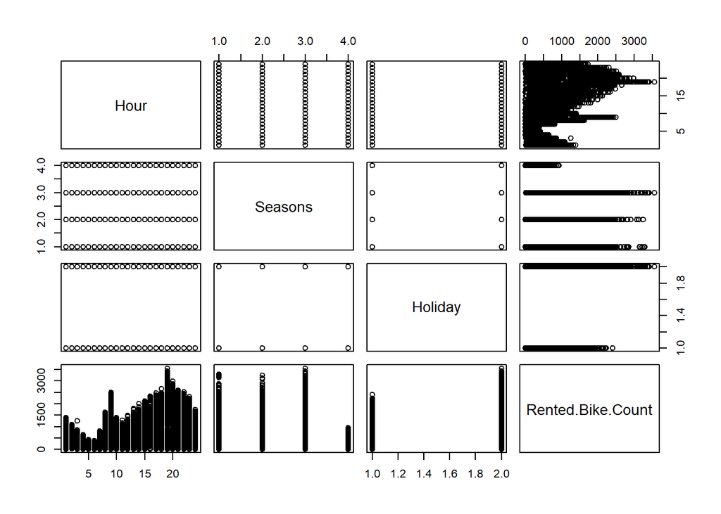

```r
plot(cbind(df_x_cate, df_y))
```

### 4.2.2 Variables visualization - continous variables.

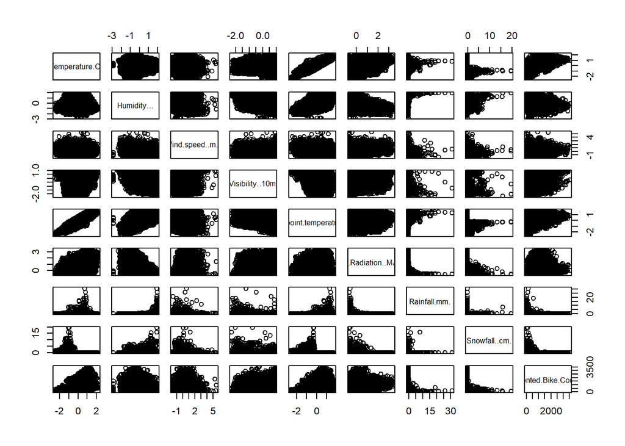

```r
plot(cbind(df_x_cont_scaled, df_y))
```

### 4.2.3 Correlation - Numerical variables.

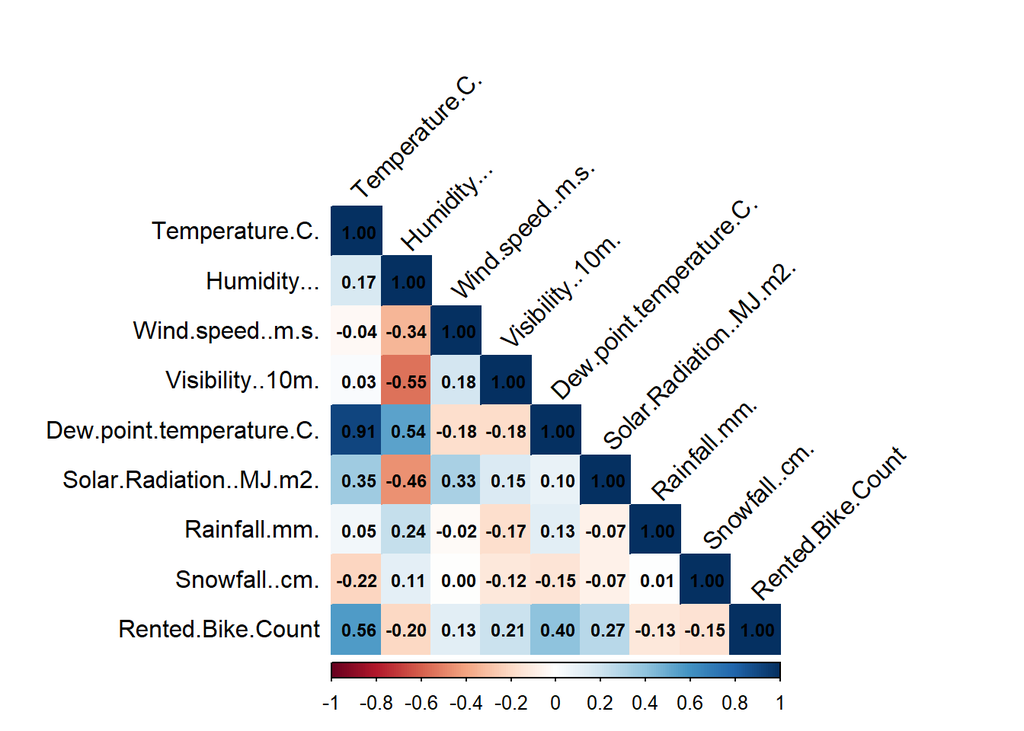

```r
correlation <- cor(x = cbind(df_x_cont_scaled, df_y), method = "pearson")

corrplot(correlation, method = "color", type = "lower", tl.col = "black", tl.srt = 45,
         addCoef.col = "black", number.cex = 0.75)
```

- Temperature and Dew.point.temperature.C have the highest correlation with the response variable.
- Which is obvious result since Temperature and Dew.point.temperature.C are highly correlated (0.91).
- Therefore, Dew.point.temperature.C variable is dropped.

### 4.2.4 Lasso regression

```r
set.seed(2024)

x_train_lasso <- train_set %>%
  dplyr::select(-Dew.point.temperature.C., -Rented.Bike.Count, -id) %>%
  dplyr::mutate_if(is.factor, as.numeric) %>%                         # Convert factors to numeric
  dplyr::mutate_if(is.character, as.numeric) %>%                      # Convert characters to numeric
  as.matrix()

y_train_lasso <- as.matrix(train_set %>% dplyr::select(Rented.Bike.Count))

cv_lasso <- cv.glmnet(x_train_lasso, y_train_lasso, alpha = 1)

opt_lambda <- cv_lasso$lambda.min                                        # find optimal lambda

mdl_lasso_reg <- glmnet(x_train_lasso, y_train_lasso, alpha = 1, lambda = opt_lambda)

print(paste("The optimal value of lambda is:", opt_lambda))
```

```
## [1] "The optimal value of lambda is: 0.847076088095222"
```

```r
print(coef(mdl_lasso_reg))
```

```
## 11 x 1 sparse Matrix of class "dgCMatrix"
##                                 s0
## (Intercept)              396.94064
## Hour                      28.07460
## Seasons                 -100.57442
## Holiday                  119.54037
## Temperature.C.           354.42361
## Humidity...             -157.66326
## Wind.speed..m.s.          14.35249
## Visibility..10m.          17.48673
## Solar.Radiation..MJ.m2.  -63.54324
## Rainfall.mm.             -68.35900
## Snowfall..cm.             14.00262
```

## 4.3 Model selection

Selected Method: Multiple Linear Regression - Lasso shrinkage.

## 4.5 Model Performance.

```r
x_test <- test_set %>%
  dplyr::select(-Dew.point.temperature.C., -Rented.Bike.Count, -id) %>%
  dplyr::mutate_if(is.factor, as.numeric) %>%                         # Convert factors to numeric
  dplyr::mutate_if(is.character, as.numeric) %>%                      # Convert characters to numeric
  as.matrix()

y_test <- as.matrix(test_set %>% dplyr::select(Rented.Bike.Count))

y_pred <- predict(mdl_lasso_reg, s = opt_lambda, newx = x_test)

print(paste("Test MES is:", sqrt(mean((y_test - y_pred)^2))))
```

```
## [1] "Test MES is: 439.13539507439"
```

# 5. Analysis assessment

## 5.1 Time series data

- Seasonal effect should have been considered.

## 5.2 Time series - Hour variable

- The trend of Hour variable is likely to have significant impact on the response variable.
- Time series analysis on Hour variable should have been included.
- Highest during rush hours.

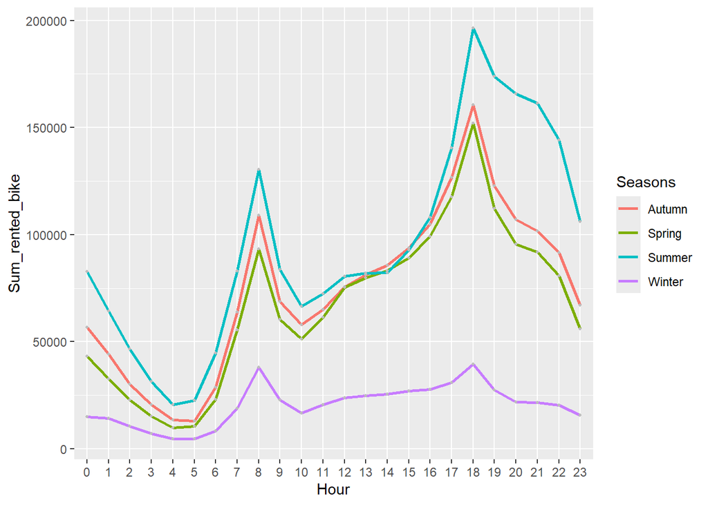

## 5.3 Generalized Linear Model.

- Response variable should be non-negative.
- Negative predicted values exist.
- GLM(Poisson, log link) could have been considered.

## 5.4 Correlation between categorical and continous variables.

- Temperature and Seasons are likely to be correlated.

# 6. Conclusion

- Multiple Linear Regression is not considered to be enough to predict bike rental counts.